# BC Student Grade-to-Grade Transitions

## Introduction

It is critical for the effectivess of any educational program that its students progress smoothly between grade levels. The BC Ministry of Education has released [data](https://catalogue.data.gov.bc.ca/dataset/bc-schools-grade-to-grade-transition) on grade-to-grade transitions categorized by a number of discriminating features, of which we will examine

1. `BASE_YEAR` / `SCHOOL_YEAR`: the transition reference year
2. `PUBLIC_OR_INDEPENDENT`: public school vs independent school identifiers
3. `DISTRICT_NUMBER` / `DISTRICT_ NAME`: school district identifier
4. `STUDENT_GRADE`: student’s grade level in `BASE_YEAR`
5. `SUB_POPULATION`: various methods of breaking down student populations (indigenous/non-indigenous, male/female, etc.)
6. `DENOMINATOR_STUDIED_COHORT`: number of students in a particular cohort
7. `NUMERATOR_NUM_SUCCESSFUL`: number of students in a particular cohort who successfully transitioned between grades

We first load the data for `BASE_YEAR` 2015 in order to perform preliminary analyses.

```r
df = read.csv('grade_transition.csv')
df2 = df[df$BASE_YEAR=='2015/2016',]
df3 = df2[(df2$DATA_LEVEL=='District Level' |
            df2$PUBLIC_OR_INDEPENDENT=='BC Independent School' & df2$DATA_LEVEL=='Province Level')
          & (df2$SUB_POPULATION=='Indigenous' | df2$SUB_POPULATION=='Non Indigenous'),]

gtdf = df3[, c('BASE_YEAR', 'PUBLIC_OR_INDEPENDENT', 'DISTRICT_NUMBER',
                  'STUDENT_GRADE', 'SUB_POPULATION',
                  'DENOMINATOR_STUDIED_COHORT', 'NUMERATOR_NUM_SUCCESSFUL')]

head(gtdf)
```

|  | BASE_YEAR | PUBLIC_OR_INDEPENDENT | DISTRICT_NUMBER | STUDENT_GRADE | SUB_POPULATION | DENOMINATOR_STUDIED_COHORT | NUMERATOR_NUM_SUCCESSFUL |
| --- | --- | --- | --- | --- | --- | --- | --- |
| 266271 | 2015/2016 | BC Independent School | NA | 1 | Indigenous | 521 | 500 |
| 266272 | 2015/2016 | BC Independent School | NA | 1 | Non Indigenous | 5827 | 5669 |
| 266276 | 2015/2016 | BC Independent School | NA | 2 | Indigenous | 546 | 525 |
| 266277 | 2015/2016 | BC Independent School | NA | 2 | Non Indigenous | 5868 | 5727 |
| 266281 | 2015/2016 | BC Independent School | NA | 3 | Indigenous | 509 | 492 |
| 266282 | 2015/2016 | BC Independent School | NA | 3 | Non Indigenous | 5722 | 5583 |

In order to fit models to the data, we process it into a more convenient format.

```r
gtdf$BASE_YEAR = as.numeric(substr(gtdf$BASE_YEAR, 1, 4))

gtdf$PUBLIC_OR_INDEPENDENT = as.character(gtdf$PUBLIC_OR_INDEPENDENT)
gtdf[gtdf$PUBLIC_OR_INDEPENDENT=='BC Independent School',]$PUBLIC_OR_INDEPENDENT = 0
gtdf[gtdf$PUBLIC_OR_INDEPENDENT=='BC Public School',]$PUBLIC_OR_INDEPENDENT = 1
gtdf$PUBLIC_OR_INDEPENDENT = as.factor(gtdf$PUBLIC_OR_INDEPENDENT)

gtdf$SUB_POPULATION = as.character(gtdf$SUB_POPULATION)
gtdf[gtdf$SUB_POPULATION=='Indigenous',]$SUB_POPULATION=1
gtdf[gtdf$SUB_POPULATION=='Non Indigenous',]$SUB_POPULATION=0

gtdf[is.na(gtdf$DISTRICT_NUMBER),]$DISTRICT_NUMBER=0
gtdf$DISTRICT_NUMBER = as.factor(gtdf$DISTRICT_NUMBER)

gtdf$DENOMINATOR_STUDIED_COHORT = as.character(gtdf$DENOMINATOR_STUDIED_COHORT)
gtdf$NUMERATOR_NUM_SUCCESSFUL = as.character(gtdf$NUMERATOR_NUM_SUCCESSFUL)

gtdf = gtdf[gtdf$DENOMINATOR_STUDIED_COHORT!='Msk' & gtdf$NUMERATOR_NUM_SUCCESSFUL!='Msk',]

gtdf$DENOMINATOR_STUDIED_COHORT = as.numeric(gtdf$DENOMINATOR_STUDIED_COHORT)
gtdf$NUMERATOR_NUM_SUCCESSFUL = as.numeric(gtdf$NUMERATOR_NUM_SUCCESSFUL)

colnames(gtdf) = c('base_year', 'is_public', 'district_number', 'student_grade',
                   'is_indigenous', 'total', 'successful')
rownames(gtdf) = 1:length(gtdf$base_year)

gtdf$is_public = as.numeric(gtdf$is_public)
gtdf$is_indigenous = as.numeric(gtdf$is_indigenous)
gtdf$success_rate = gtdf$successful / gtdf$total
head(gtdf)
```

|  | base_year | is_public | district_number | student_grade | is_indigenous | total | successful | success_rate |
| --- | --- | --- | --- | --- | --- | --- | --- | --- |
| 1 | 2015 | 1 | 0 | 1 | 1 | 521 | 500 | 0.9596929 |
| 2 | 2015 | 1 | 0 | 1 | 0 | 5827 | 5669 | 0.9728848 |
| 3 | 2015 | 1 | 0 | 2 | 1 | 546 | 525 | 0.9615385 |
| 4 | 2015 | 1 | 0 | 2 | 0 | 5868 | 5727 | 0.9759714 |
| 5 | 2015 | 1 | 0 | 3 | 1 | 509 | 492 | 0.9666012 |
| 6 | 2015 | 1 | 0 | 3 | 0 | 5722 | 5583 | 0.9757078 |

## Preliminary Analysis

In the exploratory stage, will use visualizations to identify patterns in the data that may be quantifiable with statistical models.

### Transition Rates for Indigenous and Non-Indigenous Students

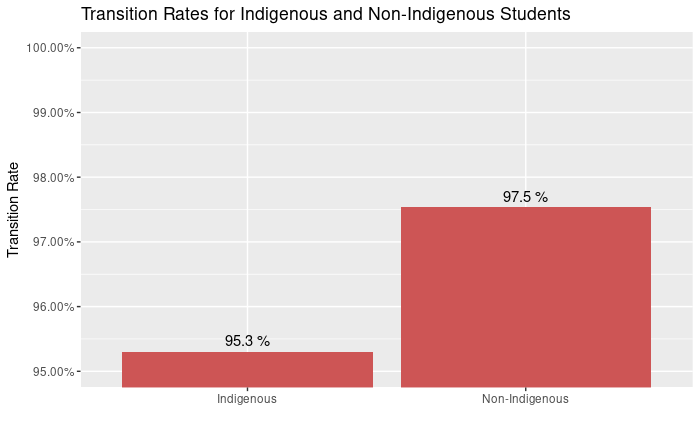

```r
agg_df = gtdf %>% group_by(is_indigenous) %>%
  summarise(total=sum(total), successful=sum(successful))
agg_df$success_rate = agg_df$successful / agg_df$total
agg_df$is_indigenous = as.character(agg_df$is_indigenous)
agg_df[agg_df$is_indigenous==1,]$is_indigenous = 'Indigenous'
agg_df[agg_df$is_indigenous==0,]$is_indigenous = 'Non-Indigenous'

ggplot(aes(is_indigenous, success_rate), data=agg_df) +
  geom_bar(stat='identity', fill='indianred3') +
  geom_text(aes(label=paste(as.character(round(success_rate*100, 1)), '%')), vjust=-0.5) +
  scale_y_continuous(limits=c(0.95, 1),
                     oob=rescale_none,
                     labels=scales::percent) +
  xlab('') + ylab('Transition Rate') +
  ggtitle('Transition Rates for Indigenous and Non-Indigenous Students')
```

It is clear that indigenous student face a considerably lower overall transition rate than non-indigenous students - this will need to be explored further.

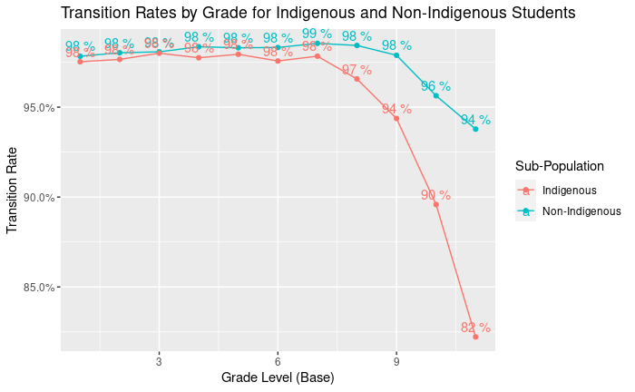

```r
agg_df = gtdf %>% group_by(is_indigenous, student_grade) %>%
  summarise(total=sum(total), successful=sum(successful))
agg_df$success_rate = agg_df$successful / agg_df$total
agg_df$is_indigenous = as.character(agg_df$is_indigenous)
agg_df[agg_df$is_indigenous==1,]$is_indigenous = 'Indigenous'
agg_df[agg_df$is_indigenous==0,]$is_indigenous = 'Non-Indigenous'

agg_df = rename(agg_df, 'Sub-Population'=is_indigenous)

ggplot(aes(student_grade, success_rate), data=agg_df) +
  geom_line(aes(color=`Sub-Population`)) +
  geom_point(aes(color=`Sub-Population`)) +
  geom_text(aes(label=paste(as.character(round(success_rate*100, 0)), '%'), color=`Sub-Population`), vjust=-0.5) +
  scale_y_continuous(labels=scales::percent) +
  xlab('Grade Level (Base)') + ylab('Transition Rate') +
  ggtitle('Transition Rates by Grade for Indigenous and Non-Indigenous Students')
```

While the discrepancy between the groups exists to some extent at all grade levels, it is most dramatic in the final 3 years, likely suggesting that many of these non-transitioning students are, in fact, dropping out of school. This is a hypothesis that ought to be explored in its on right.

### Transition Rates by School Type

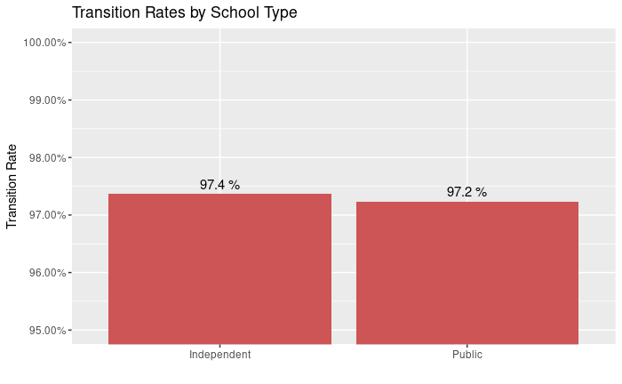

```r
agg_df = gtdf %>% group_by(is_public) %>%
  summarise(total=sum(total), successful=sum(successful))
agg_df$success_rate = agg_df$successful / agg_df$total
agg_df$is_public = as.character(agg_df$is_public)

agg_df[agg_df$is_public==2,]$is_public = 'Public'
agg_df[agg_df$is_public==1,]$is_public = 'Independent'

ggplot(aes(is_public, success_rate), data=agg_df) +
  geom_bar(stat='identity', fill='indianred3') +
  geom_text(aes(label=paste(as.character(round(success_rate*100, 1)), '%')), vjust=-0.5) +
  scale_y_continuous(limits=c(0.95, 1),
                     oob=rescale_none,
                     labels=scales::percent) +
  xlab('') + ylab('Transition Rate') +
  ggtitle('Transition Rates by School Type')
```

The overall difference between public and independent schools appears to be minimal.

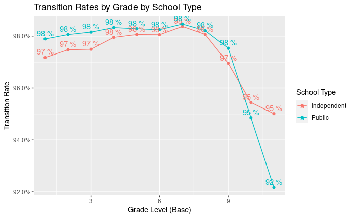

```r
agg_df = gtdf %>% group_by(is_public, student_grade) %>%
  summarise(total=sum(total), successful=sum(successful))
agg_df$success_rate = agg_df$successful / agg_df$total
agg_df$is_public = as.character(agg_df$is_public)
agg_df[agg_df$is_public==2,]$is_public = 'Public'
agg_df[agg_df$is_public==1,]$is_public = 'Independent'

agg_df = rename(agg_df, 'School Type'=is_public)

ggplot(aes(student_grade, success_rate), data=agg_df) +
  geom_line(aes(color=`School Type`)) +
  geom_point(aes(color=`School Type`)) +
  geom_text(aes(label=paste(as.character(round(success_rate*100, 0)), '%'), color=`School Type`), vjust=-0.5) +
  scale_y_continuous(labels=scales::percent) +
  xlab('Grade Level (Base)') + ylab('Transition Rate') +
  ggtitle('Transition Rates by Grade by School Type')
```

Again, we observe a drop in the final year, although not nearly as dramatic as with indigenous students (92% overall public school vs 82% overall indigenous). It is possible that students in independent schools are more likely to see 12th grade as a necessary prerequisite for attending university, while students in public schools are more likely to forgo their final year of school in order to join the workforce - this remains to be further investigated.

## Statistical Analysis

### Baseline Logistic Regression

We will establish a baseline for statistical analysis with a logistic regression on `is_public` (binary), `is_indigenous` (binary) and `student_grade` (treated as an ordinal discrete predictor)

```r
mod1 = glm(cbind(successful, total-successful) ~ is_public + student_grade + is_indigenous,
           family='binomial',
           data=gtdf)

summary(mod1)
```

```
Call:
glm(formula = cbind(successful, total - successful) ~ is_public +
    student_grade + is_indigenous, family = "binomial", data = gtdf)

Deviance Residuals:
     Min        1Q    Median        3Q       Max
-14.6560   -0.8097    0.4147    1.4140    9.2477

Coefficients:
               Estimate Std. Error z value Pr(>|z|)
(Intercept)    4.553178   0.054346  83.782   <2e-16 ***
is_public      0.063606   0.026806   2.373   0.0177 *
student_grade -0.148141   0.002922 -50.692   <2e-16 ***
is_indigenous -0.694148   0.021610 -32.122   <2e-16 ***
---
Signif. codes:  0 ‘***’ 0.001 ‘**’ 0.01 ‘*’ 0.05 ‘.’ 0.1 ‘ ’ 1

(Dispersion parameter for binomial family taken to be 1)

    Null deviance: 9678.2  on 1226  degrees of freedom
Residual deviance: 6084.7  on 1223  degrees of freedom
AIC: 9851.7

Number of Fisher Scoring iterations: 5
```

All parameters are statistically significant at the 95% confidence level. We interpret the fitted coefficients in terms of their multiplicative effects on the odds $\frac{p}{1-p}$ of transitioning between grades.

```r
exp(mod1$coefficients)-1
```

```
  (Intercept)     is_public student_grade is_indigenous
  93.93363517    0.06567196   -0.13769011   -0.50050012
```

1. Attending public school increases the odds of transitioning by 6%
2. Each increase in grade level decreases the odds of transitioning by 14%
3. Being indigenous decreases the odds of transitioning by 50%

Because the tail probability for `is_public` is relatively large compared to `student_grade` and `is_indigenous` (and drawing on our previous intuition), we will attempt to remove that parameter from the model.

```r
mod2 = glm(cbind(successful, total-successful) ~ student_grade + is_indigenous,
           family='binomial',
           data=gtdf)
summary(mod2)
```

```
Call:
glm(formula = cbind(successful, total - successful) ~ student_grade +
    is_indigenous, family = "binomial", data = gtdf)

Deviance Residuals:
     Min        1Q    Median        3Q       Max
-14.5989   -0.7780    0.4295    1.4262    9.3327

Coefficients:
               Estimate Std. Error z value Pr(>|z|)
(Intercept)    4.669504   0.023703  197.00   <2e-16 ***
student_grade -0.147805   0.002918  -50.65   <2e-16 ***
is_indigenous -0.690303   0.021546  -32.04   <2e-16 ***
---
Signif. codes:  0 ‘***’ 0.001 ‘**’ 0.01 ‘*’ 0.05 ‘.’ 0.1 ‘ ’ 1

(Dispersion parameter for binomial family taken to be 1)

    Null deviance: 9678.2  on 1226  degrees of freedom
Residual deviance: 6090.2  on 1224  degrees of freedom
AIC: 9855.3

Number of Fisher Scoring iterations: 5
```

The simplified model $\mathcal{M}_2$is nested within the previous model $\mathcal{M}_1$ , and it therefore has a `\chi^2_1` distribution under the null hypothesis that $\mathcal{M}_2$ is not an adequate simplification of $\mathcal{M}_1$

```r
pchisq(mod2$deviance - mod1$deviance,
       mod2$df.residual - mod1$df.residual,
       lower.tail=FALSE)
```

```
[1] 0.01849936
```